# Hopper Take Home: Senior DS

## Exercise 1: Distance

The first exercise asks us 'Given the table of airports and locations (in latitude and longitude) below, write a function that takes an airport code as input and returns the airports listed from nearest to furthest from the input airport.' There are three steps here:

1. Implement Distance Algorithm
2. Apply distance formula across all airports other than the input
3. Return sorted list of airports Distance

```python
#start by grabbing the necessary data
import pandas as pd
airport_distance_df = pd.read_csv('ex1_table.csv')
airport_distance_df.head()
```

|  | Airport Code | Lat | Long |
| --- | --- | --- | --- |
| 0 | CDG | 49.012798 | 2.550000 |
| 1 | CHC | -43.489399 | 172.531998 |
| 2 | DYR | 64.734901 | 177.740997 |
| 3 | EWR | 40.692501 | -74.168701 |
| 4 | HNL | 21.318701 | -157.921997 |

From my time in election science, I know that the haversine distance is a good approximation for distance. At least good enough to get the distance between airports! Haversine distances can be off by up to .5%, because the earth is not actually a sphere. It looks like the latitudes and longitudes are in degrees, so I'll make sure to have a way to account for that as well. The haversine distance formula is labeled below.

[figure not shown]

```python
from math import radians, sin, cos, atan2, sqrt
def haversine_distance(long1, lat1, long2, lat2, degrees=False):
    #degrees vs radians
    if degrees == True:
        long1 = radians(long1)
        lat1 = radians(lat1)
        long2 = radians(long2)
        lat2 = radians(lat2)

    #implementing haversine
    a = sin((lat2-lat1) / 2)**2 + cos(lat1) * cos(lat2) * sin((long2-long1) / 2)**2
    c = 2*atan2(sqrt(a), sqrt(1-a))
    distance = 6371 * c #radius of earth in kilometers
    return(distance)
```

```python
haversine_distance(long1 = 2.550000, long2 = 172.531998, lat1 = 49.012798, lat2 = -43.489399, degrees=True)
```

```
19031.31249786713
```

```python
def get_distance_list(airport_dataframe, airport_code):
    df = airport_dataframe.copy()
    row = df[df.loc[:,'Airport Code'] == airport_code]
    lat = row['Lat']
    long = row['Long']
    df = df[df['Airport Code'] != airport_code]
    df['Distance'] = df.apply(lambda x: haversine_distance(lat1=lat, long1=long, lat2 = x.Lat, long2 = x.Long, degrees=True), axis=1)
    return(df.sort_values(by='Distance').reset_index()['Airport Code'])
```

```python
get_distance_list(airport_dataframe=airport_distance_df, airport_code='CDG')
```

```
0    EWR
1    OME
2    DYR
3    PEK
4    HNL
5    ONU
6    CHC
Name: Airport Code, dtype: object
```

This all seems to work just fine! There are a few ways I would improve this if I was working on this for a longer period of time.

## Exercise 2: Testing

One of Hopper’s innovative products is “Price Freeze” which allows users to freeze a price for a period of time before purchasing the ticket. Suppose we are running a test comparing the current best model for pricing a Price Freeze (the Champion) and a new model we think might be better (the Challenger). We run the test showing these two different variants to our users but we realize there is an issue! The model is being shown to different numbers of people on different mobile devices (iOS and Android) and some of the users are also seeing a discount being offered. This makes the results of the test a bit hard to interpret. Given this table of information about our test:

Answer the following questions about the experiment, make sure to show any code, math, or reasoning you have for choosing your answer.

1. What is the probability that the Challenger is the superior model?
2. Based on your answer to number 1, would you be comfortable deciding yes/no on whether or not to change models?
3. If we decide to switch exclusively to the Challenger model for our iOS users, do we have a reasonable chance at getting 500 prices freezes in the first 10,000 views? what about 600?

```python
#first, let's look at the data
freezes_df = pd.read_csv('ex2_table.csv')
freezes_df['perc_price_freeze'] = freezes_df['price_freezes'] / freezes_df['total_views']
freezes_df.sort_values(by = ['device_type', 'discount'])
```

|  | device_type | variant | discount | total_views | price_freezes | perc_price_freeze |
| --- | --- | --- | --- | --- | --- | --- |
| 0 | android | Challenger | False | 6010 | 189 | 0.031448 |
| 2 | android | Champion | False | 1084 | 23 | 0.021218 |
| 1 | android | Challenger | True | 331 | 16 | 0.048338 |
| 3 | android | Champion | True | 54 | 3 | 0.055556 |
| 4 | iOS | Challenger | False | 6905 | 336 | 0.048660 |
| 6 | iOS | Champion | False | 6576 | 266 | 0.040450 |
| 5 | iOS | Challenger | True | 1986 | 196 | 0.098691 |
| 7 | iOS | Champion | True | 2054 | 161 | 0.078384 |

There is actually a ton of data here, the easiest way to do this is to run a regression (specifically, anova) where we estimate the effect of variant, device type, and discount on price freezes. In order to do this, we're going to need to first get the data out of the grouped format, fit our model, and then measure the p value. price_freeze ~ variant, device_type, discount and then measure the effect of the variant.

```python
#first we get the data in an unaggregated format
for i in freezes_df.index:
    x = freezes_df.iloc[[i], :3]
    #price_freezes
    freezes = pd.DataFrame(pd.np.repeat(x.values, freezes_df.iloc[i, 4], axis=0), columns = x.columns)
    freezes['price_freeze'] = 1
    #not_freezes
    freezes_false = pd.DataFrame(pd.np.repeat(x.values, (freezes_df.iloc[i, 3] - freezes_df.iloc[i, 4]), axis=0), columns = x.columns)
    freezes_false['price_freeze'] = 0
    if i == 0:
        df = pd.concat([freezes, freezes_false])
    else:
        combined = pd.concat([freezes, freezes_false])
        df = pd.concat([df, combined])
df.head()
```

|  | device_type | variant | discount | price_freeze |
| --- | --- | --- | --- | --- |
| 0 | android | Challenger | False | 1 |
| 1 | android | Challenger | False | 1 |
| 2 | android | Challenger | False | 1 |
| 3 | android | Challenger | False | 1 |
| 4 | android | Challenger | False | 1 |

```python
#then let's use statsmodels to perform ols
import statsmodels.api as sm
from statsmodels.formula.api import ols
result = ols(formula="price_freeze ~ discount + variant + device_type", data=df).fit()
sm.stats.anova_lm(result)
```

|  | df | sum_sq | mean_sq | F | PR(>F) |
| --- | --- | --- | --- | --- | --- |
| discount | 1.0 | 7.509315 | 7.509315 | 167.012882 | 4.402298e-38 |
| variant | 1.0 | 0.143924 | 0.143924 | 3.200975 | 7.360649e-02 |
| device_type | 1.0 | 1.820313 | 1.820313 | 40.485135 | 2.015499e-10 |
| Residual | 24996.0 | 1123.882448 | 0.044962 | NaN | NaN |

As we can see from this, there is around a 93% chance that the Challenger is the superior model, controlling for platform and discount differences. This isn't exactly how p values work, but it a reasonable interpretation for the question at hand. The second question is the most important one, should we actually deploy this model? The crucial step here is to **not be asking this after the experiment ends.** We should already have predefined success criteria, and this p value should fit neatly into it. If I was to set this experiment up, I would have set a requirement that the model get results that hit a p value of .05 or lower, and would have set up the sample size requirements such that if the model were actually better, we would be highly likely to get a significant result. As a result, I would not immediately deploy this model into production. However instead, re-look at the power analysis and possibly deploy the model to a small percent of users over time to get more signal into whether the model was actually superior.

Part three asks us if we switch to challenger, do we have a reasonable chance at hitting 500 price freezes in the first 10,000 attempts. I'm going to assume here that we are not going to offer a discount to any of the individuals. Generally, this is simulated by a binomial distribution, which is n successes over a period of m events. We can estimate the chance of x by sampling from the binomial in order to tell how often we'll get more than 500 and 600 price freezes. We can do this either theoretically or via a simulation, I'll do the latter.

```python
freezes_df[(freezes_df['variant'] == 'Challenger') & (freezes_df['discount'] == 0)].groupby(['variant']).sum()
```

| variant | discount | total_views | price_freezes | perc_price_freeze |
| --- | --- | --- | --- | --- |
| Challenger | False | 12915 | 525 | 0.080108 |

```python
#getting the actual ratio across ios and andriod is just the price freezes divided by the total views, or about 4%
525/12915
```

```
0.04065040650406504
```

```python
import numpy as np
ratio = 525/12915
simulated_prices = []
for i in range(0,100000):
    num_price_freezes = np.sum(np.random.binomial(1,ratio, 10000))
    simulated_prices.append(num_price_freezes)
```

```python
len([i for i in simulated_prices if i >= 500])
```

```
0
```

Using the assumptions we made, it looks like there is a near 0 chance that getting more than 500 price freezes would happen. However, let's change one of the assumptions, specifically the assumption that we would never offer discounts. What if we offered discounts at the same rate as in the experiment?

```python
freezes_df[(freezes_df['variant'] == 'Challenger')].groupby(['variant']).sum()
```

| variant | discount | total_views | price_freezes | perc_price_freeze |
| --- | --- | --- | --- | --- |
| Challenger | 2.0 | 15232 | 737 | 0.227137 |

```python
new_ratio = 737/15232
simulated_prices_new = []
for i in range(0,100000):
    num_price_freezes = np.sum(np.random.binomial(1,new_ratio, 10000))
    simulated_prices_new.append(num_price_freezes)
```

```python
len([i for i in simulated_prices_new if i >= 500])
```

```
23236
```

```python
import matplotlib.pyplot as plt
```

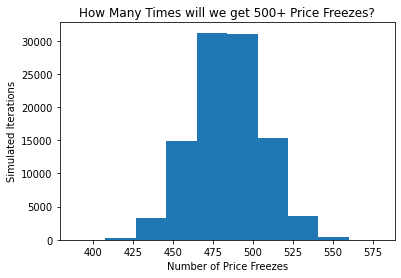

```python
plt.hist(simulated_prices_new)
plt.xlabel('Number of Price Freezes')
plt.ylabel('Simulated Iterations')
plt.title('How Many Times will we get 500+ Price Freezes?')
```

In this case, we get more than 500 price freezes around 23% percent of the time, which seems like a reasonable chance for me. Using the same graph, we can see that there is a near 0 chance of getting 600 price freezes in the first 10,000 uses.

### Exercise 3 - Representation

1. How would you transform this collection of searches into a numeric vector representing a trip? Assume that we have hundreds of thousands of users and we want to represent all of their trips this way. We ideally want this to be a general representation we could use in multiple different modeling projects, but we definitely care about finding similar trips.
2. How, precisely, would you compare two trips to see how similar they are?
3. What information do you feel might be missing from data above that would be helpful in improving your representation?

For this transformation, there are a few things that I would start with. First, I would have to define what a unique trip actually was. In order to do this, I would group by the origin, the destination, and the departure date (for the departure date, often customers will change around this departure date, so we should group by the date plus or minus at least 1 buffer day to capture all the correct dates). Additionally, we can see that often users search from an entire city, and then shrink that down into a specific airport. So we should also consider a group of individual queries from cities and airpots in the same city, as the same search, and do the same for destination.  
From that point, we should add these important columns to each unique search.

1. userid  
   This one is self-explanatory, we're going to need to know who did the search if we're going to join this dataset with user specific data
2. Number of queries  
   How many unique queries are in each search?
3. Round_trip vs One Way  
   We can set this to a boolean, 1 for round trip and 0 for one way
4. Distance  
   We should find the average distance between the destination and the origin using the method described in Q1, and add that into our vector.
5. Number of unique destinations  
   Are users changing the airports they're flying to? E.g. Flying to SFO vs Oakland's Airport
6. Number of unique origins Are users changing the airports they're flying from?
7. Datetime first searched We can represent the time purely in UNIX time, which would satisfy the numeric requirement while adding potential signal
8. Average Length of Stay  
   This would be computed by a simple average of the stay column across searches
9. Length of Search  
   This would be the difference, in seconds, between the first and last search and could be a proxy for when people decide to book a trip

For answering the second question, we should take the euclidian distance on two normalized vectors. There are three solid options for comparing two entirely numeric rows, the euclidian distance (which is just the straight line difference between two values), the manhattan distance (think of this as the distance traveled if you had to use city blocks to travel diagonally across manhattan), and the minkowsky distance (which is a generalization between the two). Because we have normalized data, and the data is not high dimensional or sparse, I would recommend using the euclidian distance to start off. This distance would tell us how similar two trips were.

The biggest missing aspect of the data above is the inability to tell when a user booked a trip on Hopper. Without this, we're missing a huge signal that hopper has, and losing the ability to answer practical questions using this dataset. One other piece of info that I noticed was missing and might be useful was the device used during the search, specifically if the user was logged in to hopper during that session on their normal mobile device or on a separate mobile device like their ipad. This is not particularly prescient, as Hopper is mobile only, but could prove useful.

## Exercise 4

An essential job of Hopper data science is coming up with new models for our products and testing to both see which models are better and to learn more about our products to help us better understand how to improve our models. One of the core features of the Hopper app is that it advises users whether to buy a ticket now or wait for the price to go down and book later. But what if our buy recommendation is wrong and the price in fact drops after the user books on Hopper? To lower the pain when this happens Hopper has introduced “Price Drop” which refunds users a certain % of the fare difference if the price drops after they book.  
If you were the data scientist in charge of this project what information would you want to track to decide whether this feature is successful? What would you track to determine how to improve this feature?

The price drop feature is incredibly interesting, because it is fundamentally a bet on the quality of Hopper's models. Of course, Hopper would want the winning side of that bet to be on their models. For this project, there are a few metrics that I would track to determine success (in order of importance). Note that I am assuming the user does not pay for this feature.

1. Price Drops over time  
   This is strictly the number of times that the model has underperformed, and people have gotten a refund on account of this feature. It is the most basic metric for success, and actually is better if it goes down over time rather than up, as this would indicate a higher quality model.
2. Dollar Amount of Total Refunds Given  
   This metric would detect if the model is underperforming on more expensive tickets. So if the model has 99% accuracy, but underperforms severely on the most expensive 1% of tickets, Hopper will lose significant capital from this feature. Closely monitoring this metric would be vital to the success of the feature.
3. Churn Rate of Customers who received Refunds  
   The whole purpose of this feature is to increase the use of Hopper over time, and this only happens if the churn rate of customers who get this feature is lower than comparable users who don't get this feature. If users are getting refunds, but are never coming back, then this feature is essentially useless.

These three metrics could be used to both judge the success of the feature, and to determine potential improvements as well.